# PA1_template

## Part 4 - Imputing missing values

There are a number of days/intervals where there are missing values coded as NA. These must be addressed to avoid introducing bias into some calculations or summaries of the data.

#### 1. Calculate and report the total number of missing values in the dataset.

```r
sum(is.na(activity[,1]))
```

```
## [1] 2304
```

There are 2304 missing values in the dataset.

#### 2. Devise a strategy to fill in missing values in the dataset.

```r
avg_steps <- mean(StepsByInterval$steps)
```

#### 3. Create a new dataset that is equal to the original dataset, but with the missing data filled in.

```r
missing <- is.na(activity[, 1])

activity_imputed <- activity
activity_imputed[missing, 1] <- avg_steps

head(activity_imputed)
```

```
##     steps       date interval
## 1 37.3826 2012-10-01        0
## 2 37.3826 2012-10-01        5
## 3 37.3826 2012-10-01       10
## 4 37.3826 2012-10-01       15
## 5 37.3826 2012-10-01       20
## 6 37.3826 2012-10-01       25
```

#### 4. Make a histogram of the number of steps taken each day, and calculate the mean and median total number of steps taken per day.

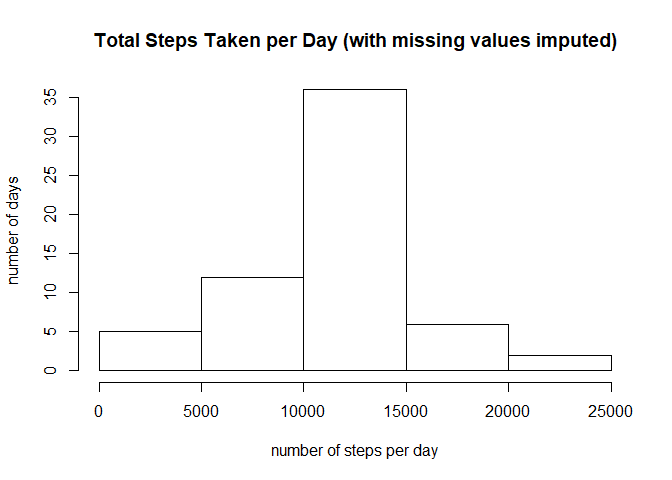

```r
StepsByDay_imputed <- aggregate(steps~date, activity_imputed, sum)

hist(StepsByDay_imputed$steps, xlab = "number of steps per day", ylab = "number of days", main = "Total Steps Taken per Day (with missing values imputed)")
```

```r
mean(StepsByDay_imputed$steps)
```

```
## [1] 10766.19
```

```r
median(StepsByDay_imputed$steps)
```

```
## [1] 10766.19
```

With the missing data filled in, the new mean (using imputed data) does not differ from the old mean, while the new median is bit higher than the old median. Also, the new mean and new median are now the same. These results are unsurprising because I used the mean (average) number of steps per interval to fill in the 2304 missing values.

## Part 5 - Are there differences in activity patterns between weekdays and weekends?

#### 1. Create a new factor variable in the dataset with two levels - weekday and weekend.

```r
library(dplyr)
activity_imputed$date <- as.Date(activity_imputed$date)

activity_DOW <- activity_imputed %>%
        mutate(DayType = ifelse(weekdays(activity_imputed$date)=="Saturday" | weekdays(activity_imputed$date)=="Sunday", "weekend", "weekday"))

head(activity_DOW)
```

```
##     steps       date interval DayType
## 1 37.3826 2012-10-01        0 weekday
## 2 37.3826 2012-10-01        5 weekday
## 3 37.3826 2012-10-01       10 weekday
## 4 37.3826 2012-10-01       15 weekday
## 5 37.3826 2012-10-01       20 weekday
## 6 37.3826 2012-10-01       25 weekday
```

#### 2. Make a panel plot containg a time series plot of the 5-minute interval and the average number of steps taken, averaged across all weekdays or weekends.

```r
library(ggplot2)
StepsByInterval_DayType <- aggregate(steps~interval + DayType, activity_DOW, mean)

head(StepsByInterval_DayType)
```

```
##   interval DayType    steps
## 1        0 weekday 7.006569
## 2        5 weekday 5.384347
## 3       10 weekday 5.139902
## 4       15 weekday 5.162124
## 5       20 weekday 5.073235
## 6       25 weekday 6.295458
```

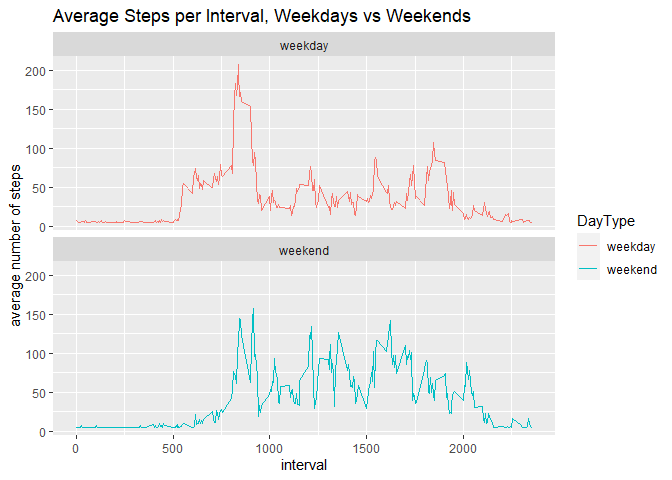

```r
plot <- ggplot(StepsByInterval_DayType, aes(x = interval, y = steps, color = DayType)) +
        geom_line() +
        labs(title = "Average Steps per Interval, Weekdays vs Weekends", x = "interval", y = "average number of steps") +
        facet_wrap(~DayType, ncol = 1, nrow = 2)
print(plot)
```